# Statistiek I - Lab session 5

# 6 Exercise 5

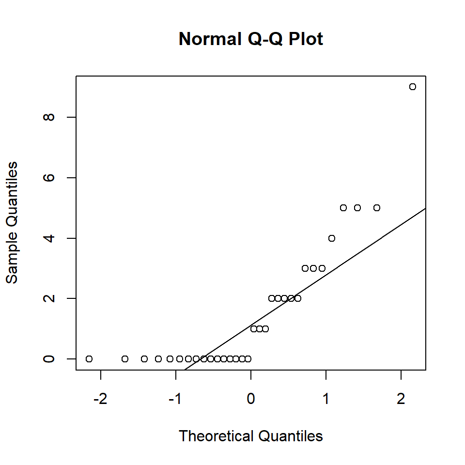

```r
#Q-Q plot to check if data is normally distributed
qqnorm(smp$age_writing - smp$age_listening)
qqline(smp$age_writing - smp$age_listening)
```

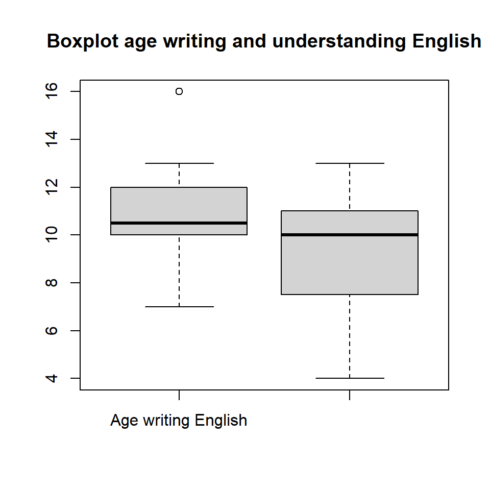

```r
#It's not, but n > 30

#Boxplot for writing and listening age
boxplot(smp$age_writing, smp$age_listening, names = c("Age writing English", "Age understanding English"), main = "Boxplot age writing and understanding English")
```

```r
#Conducting paired t-test
t.test(smp$age_writing, smp$age_listening, paired = TRUE, alternative = "greater")
```

```
##
##  Paired t-test
##
## data:  smp$age_writing and smp$age_listening
## t = 4.1028, df = 31, p-value = 0.0001371
## alternative hypothesis: true difference in means is greater than 0
## 95 percent confidence interval:
##  0.9167871       Inf
## sample estimates:
## mean of the differences
##                  1.5625
```

```r
#Calculating effect size
cohen.d(smp$age_writing, smp$age_listening, paired = TRUE)
```

```
##
## Cohen's d
##
## d estimate: 0.6947299 (medium)
## 95 percent confidence interval:
##     lower     upper
## 0.3176077 1.0718521
```

I tested whether the average age of students following Statistiek 1 at which they started to write English is higher than when they learned speak English. Our hypotheses were: **$H_0$: Age writing English = Age speaking English** and **$H_a$: Age writing English > Age speaking English**. We obtained the English grades in a **sample of 32 students** of the Statistiek 1 course via an online questionnaire, where 16 respondents did follow a bilingual education and 16 did not. This sample was taken out of a **population of 502 students** of the Statistiek 1 course, collected via an online questionnaire. Since σ is unknown, the data is not normally distributed but does contain > 30 pairs, we conducted a **paired t-test** after verifying that the assumptions for the test were met (not normally distributed (see Q-Q plots), but > 30 pairs and of same scale (age). The mean of the age when students started writing English was 10.7 and understanding (listening) English was 9.1. The **effect size was medium** (Cohen’s d: 0.6947299), and it reached significance at **α-level 0.05: t(31) = 4.1028, p = 0.0001371**. We therefore **reject the null hypothesis and accept the alternative hypothesis** that age of students at which they started writing English is higher than when they understood it, because 0.0001371 is lower than 0.05.

# 7 Exercise 6

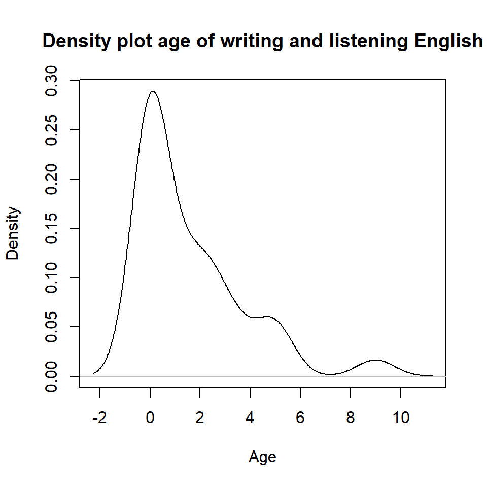

```r
#Determining if we should use a Wilcoxon signed-rank test or a Sign test
plot(density(smp$age_writing - smp$age_listening), main = "Density plot age of writing and listening English", xlab = "Age")
```

```r
#Since the data is not symmetric, we should use a Sign test

#Conducting sign test
signs <- sign(smp$age_writing - smp$age_listening)
binom.test(x = sum(signs == 1), n = 32, p = 0.5, alternative = "greater")
```

```
##
##  Exact binomial test
##
## data:  sum(signs == 1) and 32
## number of successes = 16, number of trials = 32, p-value = 0.57
## alternative hypothesis: true probability of success is greater than 0.5
## 95 percent confidence interval:
##  0.3441486 1.0000000
## sample estimates:
## probability of success
##                    0.5
```

```r
#Calculating effect size
#P-value
pval <- 0.57

#Z-value
zval <- qnorm(pval, lower.tail = FALSE)

#Effect size
n <- 16
(effectsize <- zval / sqrt(n))
```

```
## [1] -0.04409354
```

My conclusion would have been different, because the p-value of the Sign test is 0.57. Since 0.57 is higher than 0.05 I would have instead accepted the null hypothesis and rejected the alternative hypothesis.